# Wk 5 Homework

Idil Karen Sahin

## [Q1] If no intervention were in place, what would happen? Plot your results (e.g. cumulative incidence or weekly incidence) and describe what you found (1 pt)

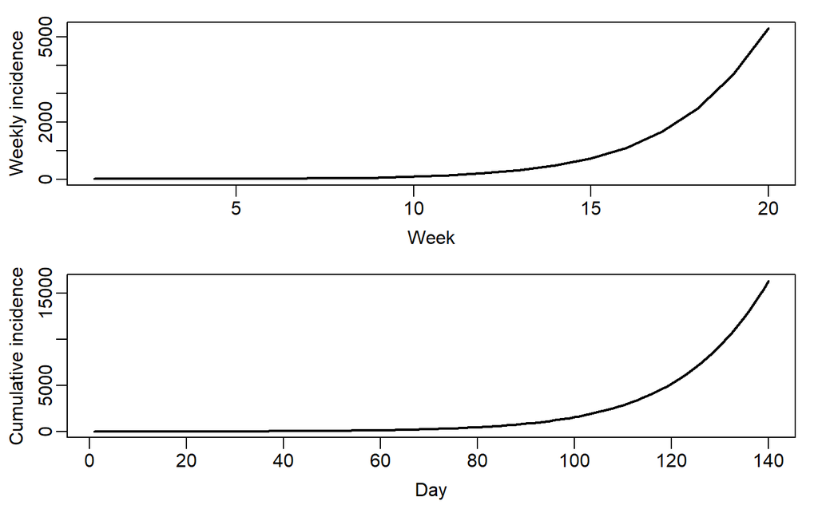

```r
library(deSolve)

EBOLA=function(t,state,parameters){
  with(as.list(c(state,parameters)),{

    # rate of change
    dS =  -S/N * (beta.I * I + beta.H * H + beta.F * FF);
    dE = S/N * (beta.I * I + beta.H * H  +  beta.F * FF)  -  alpha * E
    dI = alpha * E - I * (gamma.h * theta1 + gamma.d * (1 - theta1) * delta1 + gamma.i * (1 - theta1) * (1 - delta1));
    dH = gamma.h * theta1 * I - gamma.dh * delta2 * H  -  gamma.ih * (1 - delta2) * H
    dFF =  gamma.dh * delta2 * H  +  gamma.d * (1 - theta1) * delta1 * I  -  gamma.f * FF
    dR =  gamma.f * FF  +  gamma.i * (1 - theta1) * (1 - delta1) * I  +  gamma.ih * (1 - delta2) * H

    dcumInci = alpha * E # cumulative incidence

    # return the rate of change
    list(c(dS,  dE,  dI,  dH,  dFF,  dR,  dcumInci))
  }) # end with(as.list...)
}


# Initial conditions:
N=2e5; E0=H0=FF0=R0=0; I0=3; cumInci0=3; S0=N-I0;
state=c(S=S0,E=E0,I=I0,H=H0,FF=FF0,R=R0,cumInci=cumInci0);

## parameters for the DRC 1995 outbreak (Tables 3 & 4 in Legrand et al. 2007)
# no intervention
alpha=1/7; # incubation period: 7 days
gamma.h=1/5; # from onset to hopspitalization: 5 days
gamma.d=1/9.6; # from onset to death: 9.6 days
gamma.i=1/10; # from onset to end of infectiousness for survivors: 10 days
gamma.f=1/2; # from death to traditional burial 2 days
gamma.ih=1/(10-5); # from hospitalization to end of infectiousness for survivors
gamma.dh=1/(9.6-5); # from hospitalization to death
theta1=.67; # proportion infectious in the hospital
delta1=.8; # CFR for unhospitalized
delta2=.8; # CFR for hospitalized
p=.85; ## reduced by a factor of p as we are running it deterministically
beta.I=.588/7; # transmission rate in the community
beta.H=.794/7; # transmission rate in the hospital
beta.F=7.653/7 * p # transmission rate at funerals;

# parms without intervention
parmsNoCtrl=c(alpha=alpha, # incubation period: 7 days
              gamma.h=gamma.h, # from onset to hopspitalization: 5 days
              gamma.d=gamma.d, # from onset to death: 9.6 days
              gamma.i=gamma.i, # from onset to end of infectiousness for survivors: 10 days
              gamma.f=gamma.f, # from death to traditional burial 2 days
              gamma.ih=gamma.ih, # from hospitalization to end of infectiousness for survivors
              gamma.dh=gamma.dh, # from hospitalization to death
              theta1=theta1, # proportion infectious in the hospital
              delta1=delta1, # CFR for unhospitalized
              delta2=delta2, # CFR for hospitalize
              beta.I=beta.I, # transmission rate in the community
              beta.H=beta.H, # transmission rate in the hospital
              beta.F=beta.F # transmission rate at funerals,
);



times=1:140; # run for 20 weeks
sim=ode(y=state,times=times,func=EBOLA,parms=parmsNoCtrl);

inci=sim[seq(7,nrow(sim),by=7),'cumInci']-c(0,sim[seq(7,nrow(sim)-7,by=7),'cumInci']) # get weekly incidence

par(mfrow=c(2,1),mar=c(3,3,1,1),mgp=c(1.8,.5,0),cex=1)
plot(inci,ylab='Weekly incidence',xlab='Week',type='l',lwd=2)
plot(sim[,'cumInci'],ylab='Cumulative incidence',xlab='Day',type='l',lwd=2)
```

```r
NA
NA
```

We observe very high numbers of both cumulative and weekly incidences, furthermore the increasing curve of weekly cases implies the increasing risk of EBOLA.

### [Q2] What happened when intervention measures were implemented from Day 64 onwards? Plot your results (e.g., weekly incidence) and describe what you found.(1 pt)

```r
# parms with intervention
z=.88; # intervention in the community
z.H=.75; # intervention in the hospital
z.F=0.875; # intervention in safe burial
parmsCtrl=c(alpha=alpha, # incubation period: 7 days
            gamma.h=gamma.h, # from onset to hopspitalization: 5 days
            gamma.d=gamma.d, # from onset to death: 9.6 days
            gamma.i=gamma.i, # from onset to end of infectiousness for survivors: 10 days
            gamma.f=gamma.f, # from death to traditional burial 2 days
            gamma.ih=gamma.ih, # from hospitalization to end of infectiousness for survivors
            gamma.dh=gamma.dh, # from hospitalization to death
            theta1=theta1, # proportion infectious in the hospital
            delta1=delta1, # CFR for unhospitalized
            delta2=delta2, # CFR for hospitalize
            beta.I=beta.I * (1-z), # transmission rate in the community
            beta.H=beta.H * (1-z.H), # transmission rate in the hospital
            beta.F=beta.F * (1-z.F) # transmission rate at funerals,
);

## simulation starts on Mar 1, no intervention until May 4 (~9 weeks later)
## last case identified on July 12 (~19w weeks later)
times1=seq(1,9*7,by=1); # first 9 weeks with out intervention
times2=seq(9*7, 20*7,by=1); # afterward with incidence

# Stage 1: no intervention
simNoCtrl=ode(y=state,times=times1,func=EBOLA,parms=parmsNoCtrl);

# Stage 2: yes intervention
state2=c(S=tail(simNoCtrl[,'S'],1),E=tail(simNoCtrl[,'E'],1),
         I=tail(simNoCtrl[,'I'],1),H=tail(simNoCtrl[,'H'],1),
         FF=tail(simNoCtrl[,'FF'],1),R=tail(simNoCtrl[,'R'],1),
         cumInci=tail(simNoCtrl[,'cumInci'],1));
simCtrl=ode(y=state2,times=times2,func=EBOLA,parms=parmsCtrl);

# Combine the two
sim2=rbind(simNoCtrl,simCtrl[-1,])

inci2=sim2[seq(7,nrow(sim2),by=7),'cumInci']-c(0,sim2[seq(7,nrow(sim2)-7,by=7),'cumInci']) # get weekly incidence


## mock data
dates=seq(as.Date('1995/3/4'),as.Date('1995/7/15'),by=7);
obs=c(4,2,5,1,7,6,18,25,58,40,52,28,16,19,4,5,0,0,1,0); # 291 cases
da=cbind(dates,obs)

## plot resultsï¼šsimulated (with intervention) v. observations
par(mfrow=c(1,1), mar=c(3,3,1,1),mgp=c(1.6,.5,0),cex=1.1)
## Note: In barplot, bars are not drawn at intervals 1:10, etc., but on something else.
## The actual x-coodinates can be seen if you save your barplot object.
df.bar=barplot(obs,col='white',xlab='Time from onset (week)',
               ylab='Weekly incidence',ylim=c(0,80))
axis(1,at=df.bar,lab=1:20)
```

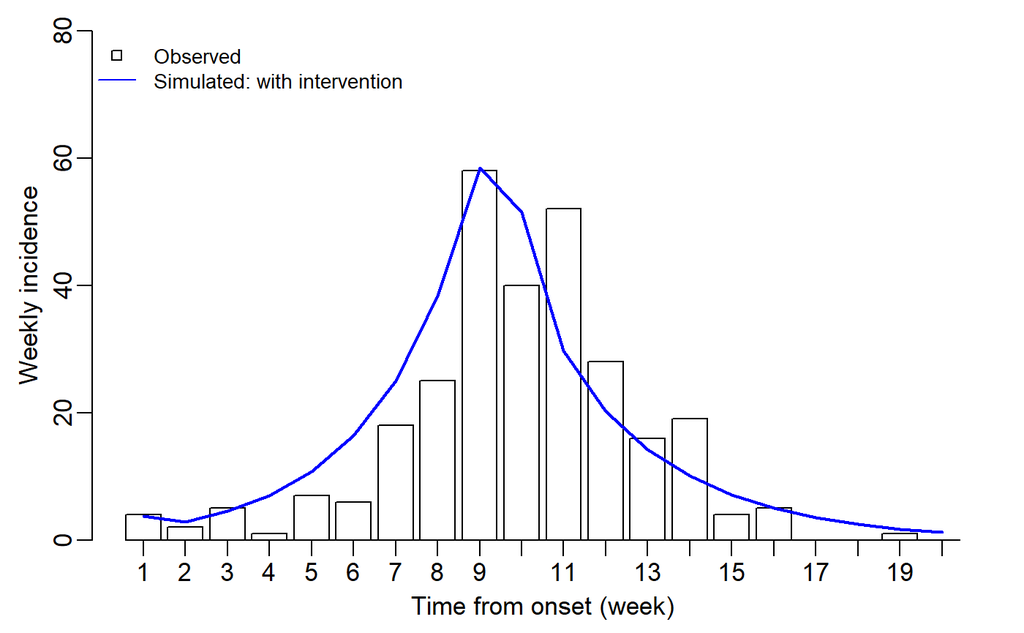

```r
lines(x=df.bar, y=inci2,lwd=2, col= "blue") # use 'x=df.bar' to match with weeks

legend('topleft',c('Observed','Simulated: with intervention'),
       lty=c(NA,1),pch=c(0, NA),col=c('black','blue'),cex=.8,bty='n')
```

- We observe that our deterministic results are not perfectly matched but close to the observation results.
- We observe increasing number of weekly cases until Week 9. The weekly incidence starts to decrease both in real observatory data and in our simulation at Week 9, the time when interventions took place.

### [Q3] Plot the observed weekly incidence, simulated weekly incidence when no intervention is implemented (from part 1), and simulated weekly incidence when intervention is implemented on Day 64 (from Q2) together. What do you think about the impact of intervention? (0.5 pt)

```r
## mock data
dates=seq(as.Date('1995/3/4'),as.Date('1995/7/15'),by=7);
obs=c(4,2,5,1,7,6,18,25,58,40,52,28,16,19,4,5,0,0,1,0); # 291 cases
da=cbind(dates,obs)

## plot resultsï¼šsimulated (with intervention) v. observations
par(mfrow=c(1,1), mar=c(3,3,1,1),mgp=c(1.6,.5,0),cex=1.1)
## Note: In barplot, bars are not drawn at intervals 1:10, etc., but on something else.
## The actual x-coodinates can be seen if you save your barplot object.
df.bar=barplot(obs,col='white',xlab='Time from onset (week)', ylab='Weekly incidence',ylim=c(0,500))
axis(1,at=df.bar,lab=1:20)
```

```r
lines(x=df.bar, y=inci2,lwd=2, col= "blue") # use 'x=df.bar' to match with weeks
lines(x=df.bar, y=inci,lwd=2, col ="red", lty = "dotted" );
```

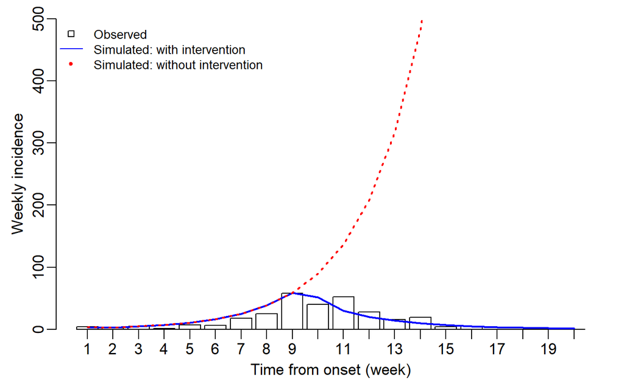

```r
legend('topleft',c('Observed','Simulated: with intervention', "Simulated: without intervention"),
       lty=c(NA,1),pch=c(0, NA, 20),col=c('black','blue', "red"),cex=.8,bty='n')
```

```r
NA
NA
NA
```

Observing the decrease in weekly incidence after interventions (after Week 9) and significant difference between incidences with and without intervention (blue and red lines), we conclude that interventions proved to be very effective.

### [Q4] Change the strength of intervention on transmission within the community (z) to 0.2, 0.4, 0.6, and 0.8 (keep other parms/settings the same), run the model for each of these different z’s, plot your results (weekly incidence) and describe what you found. (0.5 pt)

```r
z_c = c(0.2,0.4,0.8) # intervention in the community
z.H=.75; # intervention in the hospital
z.F=0.875; # intervention in safe burial
res <- matrix(0, 20, length(z_c))

for (i in 1:length(z_c)) {

  z= z_c[i]

parmsCtrl=c(alpha=alpha, # incubation period: 7 days
            gamma.h=gamma.h, # from onset to hopspitalization: 5 days
            gamma.d=gamma.d, # from onset to death: 9.6 days
            gamma.i=gamma.i, # from onset to end of infectiousness for survivors: 10 days
            gamma.f=gamma.f, # from death to traditional burial 2 days
            gamma.ih=gamma.ih, # from hospitalization to end of infectiousness for survivors
            gamma.dh=gamma.dh, # from hospitalization to death
            theta1=theta1, # proportion infectious in the hospital
            delta1=delta1, # CFR for unhospitalized
            delta2=delta2, # CFR for hospitalize
            beta.I=beta.I * (1-z), # transmission rate in the community
            beta.H=beta.H * (1-z.H), # transmission rate in the hospital
            beta.F=beta.F * (1-z.F)) # transmission rate at funerals,




## simulation starts on Mar 1, no intervention until May 4 (~9 weeks later)
## last case identified on July 12 (~19w weeks later)
times1=seq(1,9*7,by=1); # first 9 weeks with out intervention
times2=seq(9*7, 20*7,by=1); # afterward with incidence

# Stage 1: no intervention
simNoCtrl=ode(y=state,times=times1,func=EBOLA,parms=parmsNoCtrl);

# Stage 2: yes intervention
state2=c(S=tail(simNoCtrl[,'S'],1),E=tail(simNoCtrl[,'E'],1),
         I=tail(simNoCtrl[,'I'],1),H=tail(simNoCtrl[,'H'],1),
         FF=tail(simNoCtrl[,'FF'],1),R=tail(simNoCtrl[,'R'],1),
         cumInci=tail(simNoCtrl[,'cumInci'],1));
simCtrl=ode(y=state2,times=times2,func=EBOLA,parms=parmsCtrl);



# Combine the two
sim2=rbind(simNoCtrl,simCtrl[-1,])

res[,i]=sim2[seq(7,nrow(sim2),by=7),'cumInci']-c(0,sim2[seq(7,nrow(sim2)-7,by=7),'cumInci']) # get weekly incidence


}

ymax=max(res)*1.2
par(mar=c(3,3,1,1),mgp=c(2,.5,0),cex=1.1)
df.bar=barplot(obs,col='white',xlab='Date of onset (week)',
               ylab='Weekly incidence',ylim=c(0,ymax))
axis(1,at=df.bar,lab=1:20)
```

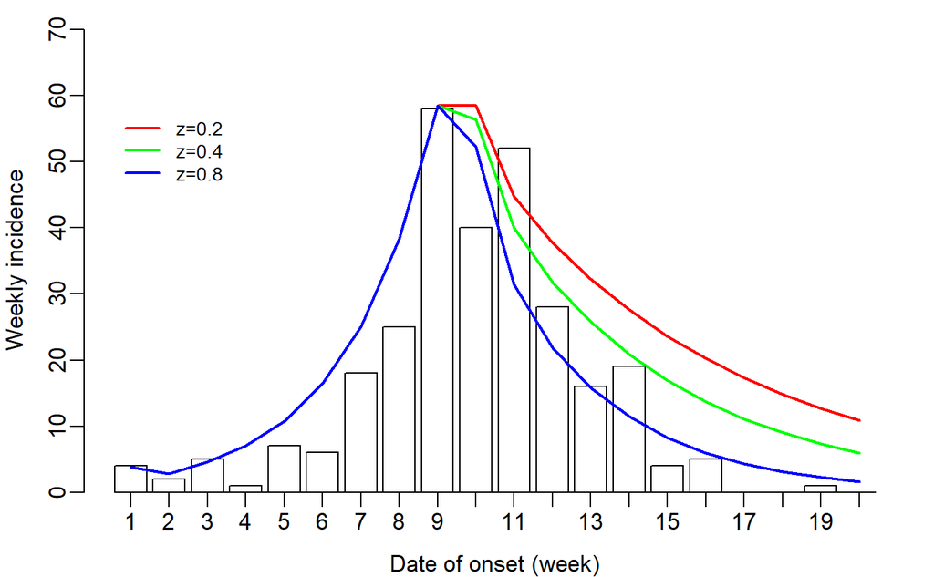

```r
matlines(x=df.bar, y=res,lty=1, lwd=2,col=rainbow(ncol(res))) # use 'x=df.bar' to match with weeks
legend(0,ymax/1.2,c(paste('z=',z_c,sep='')),
       lty=1, lwd=2,col=rainbow(ncol(res)),bty='n',cex=.8)
```

```r
NA
NA
```

### [Q5] Set z back to .88. Change the strength of intervention on transmission within the hospital (z.H) to 0.2, 0.4, 0.6, and 0.8 (keep other parms/settings the same), run the model for each of these different z.H’s, plot your results (weekly incidence) and describe what you found. (0.5 pt)

```r
z = 0.88; # intervention in the community
z.Hc =c (0.2,0.4,0.8); # intervention in the hospital
z.F=0.875; # intervention in safe burial
resH <- matrix(0, 20, length(z.Hc))

for (i in 1:length(z.Hc)) {

  z.H = z.Hc[i]

parmsCtrl=c(alpha=alpha, # incubation period: 7 days
            gamma.h=gamma.h, # from onset to hopspitalization: 5 days
            gamma.d=gamma.d, # from onset to death: 9.6 days
            gamma.i=gamma.i, # from onset to end of infectiousness for survivors: 10 days
            gamma.f=gamma.f, # from death to traditional burial 2 days
            gamma.ih=gamma.ih, # from hospitalization to end of infectiousness for survivors
            gamma.dh=gamma.dh, # from hospitalization to death
            theta1=theta1, # proportion infectious in the hospital
            delta1=delta1, # CFR for unhospitalized
            delta2=delta2, # CFR for hospitalize
            beta.I=beta.I * (1-z), # transmission rate in the community
            beta.H=beta.H * (1-z.H), # transmission rate in the hospital
            beta.F=beta.F * (1-z.F)) # transmission rate at funerals,




## simulation starts on Mar 1, no intervention until May 4 (~9 weeks later)
## last case identified on July 12 (~19w weeks later)
times1=seq(1,9*7,by=1); # first 9 weeks with out intervention
times2=seq(9*7, 20*7,by=1); # afterward with incidence

# Stage 1: no intervention
simNoCtrl=ode(y=state,times=times1,func=EBOLA,parms=parmsNoCtrl);

# Stage 2: yes intervention
state2=c(S=tail(simNoCtrl[,'S'],1),E=tail(simNoCtrl[,'E'],1),
         I=tail(simNoCtrl[,'I'],1),H=tail(simNoCtrl[,'H'],1),
         FF=tail(simNoCtrl[,'FF'],1),R=tail(simNoCtrl[,'R'],1),
         cumInci=tail(simNoCtrl[,'cumInci'],1));
simCtrl=ode(y=state2,times=times2,func=EBOLA,parms=parmsCtrl);



# Combine the two
sim2=rbind(simNoCtrl,simCtrl[-1,])

resH[,i]=sim2[seq(7,nrow(sim2),by=7),'cumInci']-c(0,sim2[seq(7,nrow(sim2)-7,by=7),'cumInci']) # get weekly incidence


}

ymax=max(resH)*1.2
par(mar=c(3,3,1,1),mgp=c(2,.5,0),cex=1.1)
df.bar=barplot(obs,col='white',xlab='Date of onset (week)',
               ylab='Weekly incidence',ylim=c(0,ymax))
axis(1,at=df.bar,lab=1:20)
```

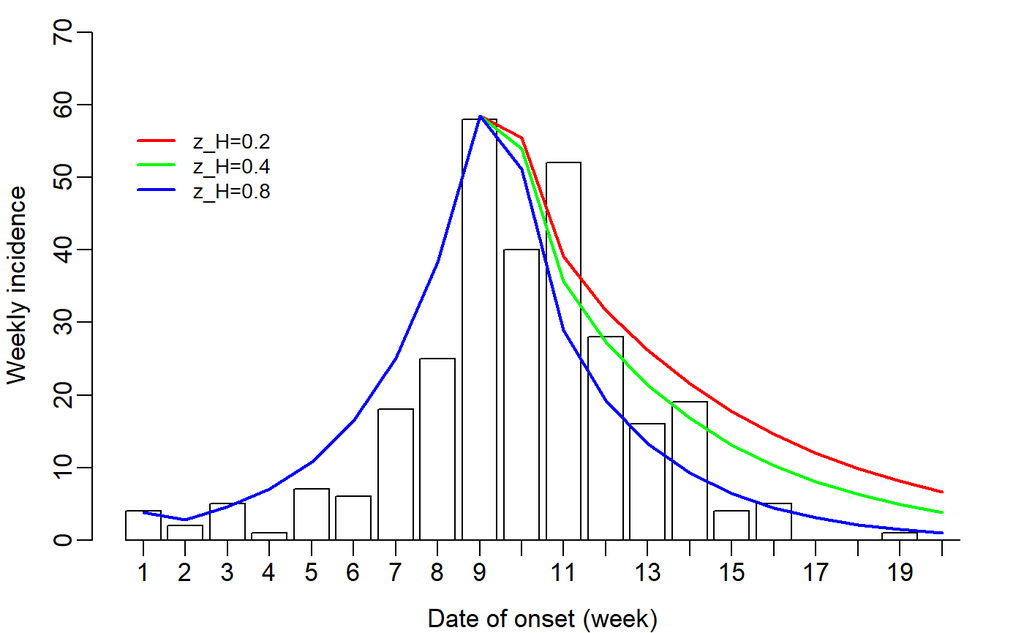

```r
matlines(x=df.bar, y=resH,lty=1, lwd=2,col=rainbow(ncol(res))) # use 'x=df.bar' to match with weeks
legend(0,ymax/1.2,c(paste('z_H=',z.Hc,sep='')),
       lty=1, lwd=2,col=rainbow(ncol(res)),bty='n',cex=.8)
```

```r
NA
NA
```

### [Q6] Set z=0.88 and z.H= 0.75. Change the strength of intervention on transmission at funerals (z.F) to 0.2, 0.4, 0.6, and 0.8 (keep other parms the same), run the model for each of these different z.F’s, plot your results (weekly incidence) and describe what you found. (0.5 pt)

```r
z = 0.88; # intervention in the community
z.H = 0.75; # intervention in the hospital
z.Fc = c(0.2,0.4,0.8); # intervention in safe burial
resF <- matrix(0, 20, length(z.Fc))

for (i in 1:length(z.Fc)) {

  z.F = z.Fc[i]

parmsCtrl=c(alpha=alpha, # incubation period: 7 days
            gamma.h=gamma.h, # from onset to hopspitalization: 5 days
            gamma.d=gamma.d, # from onset to death: 9.6 days
            gamma.i=gamma.i, # from onset to end of infectiousness for survivors: 10 days
            gamma.f=gamma.f, # from death to traditional burial 2 days
            gamma.ih=gamma.ih, # from hospitalization to end of infectiousness for survivors
            gamma.dh=gamma.dh, # from hospitalization to death
            theta1=theta1, # proportion infectious in the hospital
            delta1=delta1, # CFR for unhospitalized
            delta2=delta2, # CFR for hospitalize
            beta.I=beta.I * (1-z), # transmission rate in the community
            beta.H=beta.H * (1-z.H), # transmission rate in the hospital
            beta.F=beta.F * (1-z.F)) # transmission rate at funerals,




## simulation starts on Mar 1, no intervention until May 4 (~9 weeks later)
## last case identified on July 12 (~19w weeks later)
times1=seq(1,9*7,by=1); # first 9 weeks with out intervention
times2=seq(9*7, 20*7,by=1); # afterward with incidence

# Stage 1: no intervention
simNoCtrl=ode(y=state,times=times1,func=EBOLA,parms=parmsNoCtrl);

# Stage 2: yes intervention
state2=c(S=tail(simNoCtrl[,'S'],1),E=tail(simNoCtrl[,'E'],1),
         I=tail(simNoCtrl[,'I'],1),H=tail(simNoCtrl[,'H'],1),
         FF=tail(simNoCtrl[,'FF'],1),R=tail(simNoCtrl[,'R'],1),
         cumInci=tail(simNoCtrl[,'cumInci'],1));
simCtrl=ode(y=state2,times=times2,func=EBOLA,parms=parmsCtrl);



# Combine the two
sim2=rbind(simNoCtrl,simCtrl[-1,])

resF[,i]=sim2[seq(7,nrow(sim2),by=7),'cumInci']-c(0,sim2[seq(7,nrow(sim2)-7,by=7),'cumInci']) # get weekly incidence


}

ymax=max(resF)*1.2
par(mar=c(3,3,1,1),mgp=c(2,.5,0),cex=1.1)
df.bar=barplot(obs,col='white',xlab='Date of onset (week)',
               ylab='Weekly incidence',ylim=c(0,ymax))
axis(1,at=df.bar,lab=1:20)
```

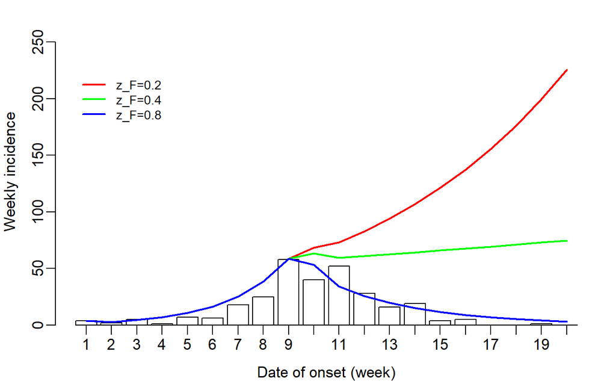

```r
matlines(x=df.bar, y=resF,lty=1, lwd=2,col=rainbow(ncol(res))) # use 'x=df.bar' to match with weeks
legend(0,ymax/1.2,c(paste('z_F=',z.Fc,sep='')),
       lty=1, lwd=2,col=rainbow(ncol(res)),bty='n',cex=.8)
```

```r
NA
NA
```

### [Q7] Set z=0.88, z.H= 0.75, z.F=0.875. Change the timing of intervention to 6, 8, 10, 12 weeks after the outbreak started (keep other parms the same), run the model for each of these different timings, plot your results (weekly incidence) and describe what you found (how important is the timing of intervention?). (0.5 pt)

```r
z = 0.88; # intervention in the community
z.H = 0.75; # intervention in the hospital
z.F = 0.875; # intervention in safe burial
Wk = c(6,8,10,12)
resW <- matrix(0, 20, length(Wk))

for (i in 1:length(Wk)) {

  week <- Wk[i]

parmsCtrl=c(alpha=alpha, # incubation period: 7 days
            gamma.h=gamma.h, # from onset to hopspitalization: 5 days
            gamma.d=gamma.d, # from onset to death: 9.6 days
            gamma.i=gamma.i, # from onset to end of infectiousness for survivors: 10 days
            gamma.f=gamma.f, # from death to traditional burial 2 days
            gamma.ih=gamma.ih, # from hospitalization to end of infectiousness for survivors
            gamma.dh=gamma.dh, # from hospitalization to death
            theta1=theta1, # proportion infectious in the hospital
            delta1=delta1, # CFR for unhospitalized
            delta2=delta2, # CFR for hospitalize
            beta.I=beta.I * (1-z), # transmission rate in the community
            beta.H=beta.H * (1-z.H), # transmission rate in the hospital
            beta.F=beta.F * (1-z.F)) # transmission rate at funerals,


## simulation starts on Mar 1, no intervention until May 4 (~9 weeks later)
## last case identified on July 12 (~19w weeks later)
times1=seq(1,week*7,by=1); # first 9 weeks with out intervention
times2=seq(week*7, 20*7,by=1); # afterward with incidence

# Stage 1: no intervention
simNoCtrl=ode(y=state,times=times1,func=EBOLA,parms=parmsNoCtrl);

# Stage 2: yes intervention
state2=c(S=tail(simNoCtrl[,'S'],1),E=tail(simNoCtrl[,'E'],1),
         I=tail(simNoCtrl[,'I'],1),H=tail(simNoCtrl[,'H'],1),
         FF=tail(simNoCtrl[,'FF'],1),R=tail(simNoCtrl[,'R'],1),
         cumInci=tail(simNoCtrl[,'cumInci'],1));
simCtrl=ode(y=state2,times=times2,func=EBOLA,parms=parmsCtrl);



# Combine the two
sim2=rbind(simNoCtrl,simCtrl[-1,])

resW[,i]=sim2[seq(7,nrow(sim2),by=7),'cumInci']-c(0,sim2[seq(7,nrow(sim2)-7,by=7),'cumInci']) # get weekly incidence


}

ymax=max(resW)*1.2
par(mar=c(3,3,1,1),mgp=c(2,.5,0),cex=1.1)
df.bar=barplot(obs,col='white',xlab='Date of onset (week)',
               ylab='Weekly incidence',ylim=c(0,ymax))
axis(1,at=df.bar,lab=1:20)
```

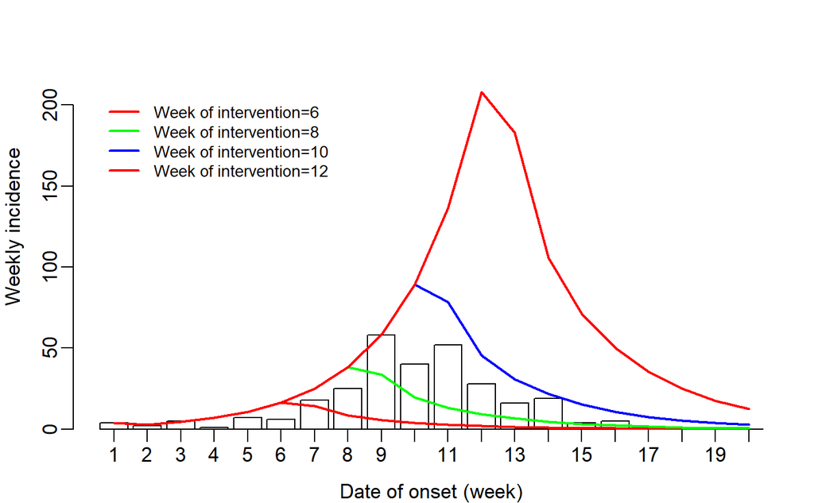

```r
matlines(x=df.bar, y=resW,lty=1, lwd=2,col=rainbow(ncol(res))) # use 'x=df.bar' to match with weeks
legend(0,ymax/1.2,c(paste('Week of intervention=',Wk,sep='')),
       lty=1, lwd=2,col=rainbow(ncol(res)),bty='n',cex=.8)
```

```r
NA
NA
```

We observe lower number of cases when interventions take place earlier in the epidemic. The difference is most visible when we compare scenarios for intervention at week 10 and 12.  
We conclude that the timing of interventions has a strong effect on the number of cases and therefore the course and outcome of the epidemic.

### [Q8] Compare the results you got for the above 4 sensitivity tests, what do you think is/are the most important intervention(s) for controlling the Kikwit outbreak? (0.5 pt)

```r
ymax=max(resF, resW, res, resH)*1.2
par(mar=c(3,3,1,1),mgp=c(2,.5,0),cex=1.1, mfrow=c(2,2));
df.bar=barplot(obs,col='white',xlab='Date of onset (week)',
               ylab='Weekly incidence',ylim=c(0,ymax))
axis(1,at=df.bar,lab=1:20)
```

```r
matlines(x=df.bar, y=resW,lty=1, lwd=2,col=rainbow(ncol(res))) # use 'x=df.bar' to match with weeks
legend(0,ymax/1.2,c(paste('Week of intervention=',Wk,sep='')),
       lty=1, lwd=2,col=rainbow(ncol(res)),bty='n',cex=.8)
```

```r
par(mar=c(3,3,1,1),mgp=c(2,.5,0),cex=1.1)
df.bar=barplot(obs,col='white',xlab='Date of onset (week)',
               ylab='Weekly incidence',ylim=c(0,ymax))
```

```r
axis(1,at=df.bar,lab=1:20)
matlines(x=df.bar, y=resF,lty=1, lwd=2,col=rainbow(ncol(res))) # use 'x=df.bar' to match with weeks
```

```r
legend(0,ymax/1.2,c(paste('z_F=',z.Fc,sep='')),
       lty=1, lwd=2,col=rainbow(ncol(res)),bty='n',cex=.8)



par(mar=c(3,3,1,1),mgp=c(2,.5,0),cex=1.1)
```

```r
df.bar=barplot(obs,col='white',xlab='Date of onset (week)',
               ylab='Weekly incidence',ylim=c(0,ymax))
axis(1,at=df.bar,lab=1:20)
```

```r
matlines(x=df.bar, y=resH,lty=1, lwd=2,col=rainbow(ncol(res))) # use 'x=df.bar' to match with weeks
legend(0,ymax/1.2,c(paste('z_H=',z.Hc,sep='')),
       lty=1, lwd=2,col=rainbow(ncol(res)),bty='n',cex=.8)
```

```r
par(mar=c(3,3,1,1),mgp=c(2,.5,0),cex=1.1)
df.bar=barplot(obs,col='white',xlab='Date of onset (week)',
               ylab='Weekly incidence',ylim=c(0,ymax))
```

```r
axis(1,at=df.bar,lab=1:20)
matlines(x=df.bar, y=res,lty=1, lwd=2,col=rainbow(ncol(res))) # use 'x=df.bar' to match with weeks
```

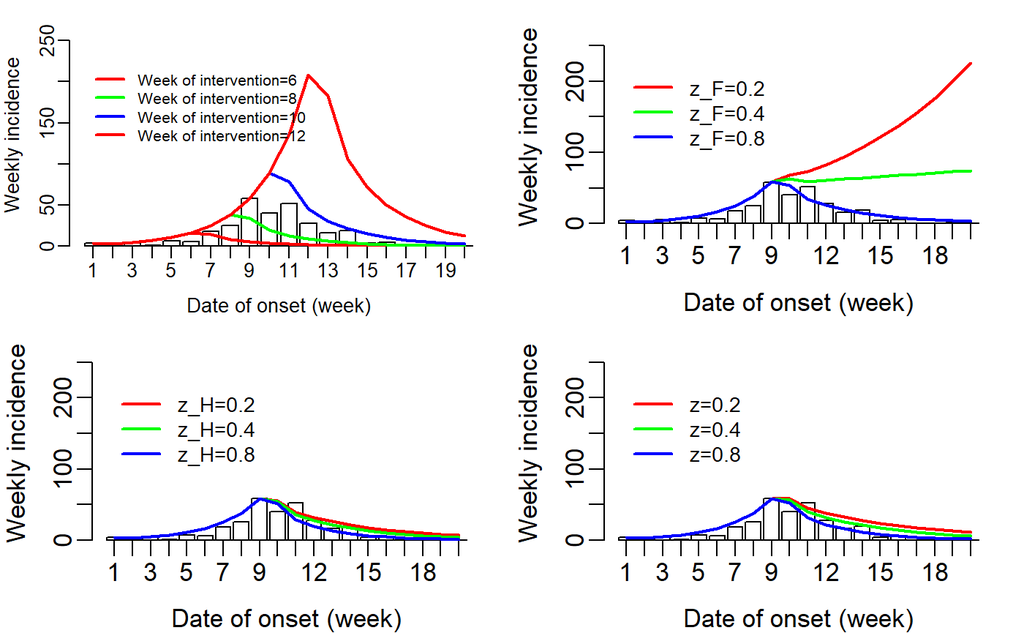

```r
legend(0,ymax/1.2,c(paste('z=',z_c,sep='')),
       lty=1, lwd=2,col=rainbow(ncol(res)),bty='n',cex=.8)
```

```r
NA
NA
NA
```

We have similar graphs for z_H and z for different values of these parameters. Meanwhile the course of the epidemic changes drastically for different values of z_F and the week of intervention. We conclude that the timing of intervention and the strength of intervention at funerals are the most important factors in controlling the Kikwit outbreak.